# Introductory Data Science & Machine Learning

## Personal Branding [SHAMELESS!!]

- **Name**: Abdullah Al Imran
- **Currently**: Data Science Trainer at Divine IT Ltd.
- **Previously**:
  - Research Assistant at Data & Design Lab, Dept. of CS, University of Dhaka. *[1.5 year]*
  - Data Scienist at Revvey Co, a New York based start-up. *[4 months]*
- **Education**: BSc. in Computer Science & Engineering, American Internaional University-Bangladesh, [14-1]
- **Connect** with me on [LinkedIn](https://www.linkedin.com/in/abdalimran/), [Facebook](https://www.facebook.com/abdalimran)
- **Email** me at abdalimran@gmail.com [I'm very active in email!!]
- **Website:** http://abdalimran.github.io
- **Recent recognition:** 1st Runner-Up at Robi-Axita Datathon 2019
- Motivation
  - An overview of Data Scales
  - A Day in Data
  - Why get into Data Science?
- Data Science: Birds Eye View
  - What is Data Science?
  - A bit of history?
  - The Data Science Venn Diagram
  - What skills do you need to be a Data Scientist?
- Machine Learning
  - What is Machine Learning?
  - Traditional Programming vs Machine Learning
  - Artificial Intelligence vs Machine Learning vs Deep Learning vs Data Mining
  - Top Industrial Applications of Machine Learning
  - Branches of Machine Learning
- The Data Science Pipeline
  - Collection
  - Exploration
  - Munging
  - Modeling
  - Validation
  - Communication
- Case Study 1: Regression
  - Problem Description
  - Solution
- Case Study 2: Classification
  - Problem Description
  - Solution
- Case Study 3: Clustering
  - Problem Description
  - Solution
- Learning Resources
- Conducting research in Applied Data Science and Machine Learning

## Motivation

### An overview of Data Scales

| Abbreviation | Unit | Value | Size (in bytes) |
| --- | --- | --- | --- |
| b | bit | 0 or 1 | 1/8 of a byte |
| B | bytes | 8 bits | 1 byte |
| KB | kilobytes | 1,000 bytes | 1,000 bytes |
| MB | megabyte | 1,000² bytes | 1,000,000 bytes |
| GB | gigabyte | 1,000³ bytes | 1,000,000,000 bytes |
| TB | terabyte | 1,000⁴ bytes | 1,000,000,000,000 bytes |
| PB | petabyte | 1,000⁵ bytes | 1,000,000,000,000,000 bytes |
| EB | exabyte | 1,000⁶ bytes | 1,000,000,000,000,000,000 bytes |
| ZB | zettabyte | 1,000⁷ bytes | 1,000,000,000,000,000,000,000 bytes |
| YB | yottabyte | 1,000⁸ bytes | 1,000,000,000,000,000,000,000,000 bytes |

### A Day in Data

Data is growing exponentially!! Let's look at this interestring infographic by RACONTEUR.

[figure not shown]

By 2025, it’s estimated that 463 exabytes of data will be created each day globally – that’s the equivalent of 212,765,957 DVDs per day!

### Why get into Data Science?

- You'll be wise, logical, knowledgable and a better human because, **Data → Information → Knowledge → Wisdom**
- Data Science will give you the joy of discovery and the power of predicting the future!!
- You'll never get bored! Every Data Science problem is a new roller-coaster ride!!
- There is no specific application domain for Data Science. Where there is data, there is Data Science. You just need to imagine!
- Data is growing exponentially. The world needs data talents to make use of the huge amount of data.
- The January 2019 report from Indeed, one of the top job sites, showed a 29% increase in demand for data scientists year over year and a 344% increase since 2013 -- a dramatic upswing. But while demand -- in the form of job postings -- continues to rise sharply, searches by job seekers skilled in data science grew at a slower pace (14%), suggesting a gap between supply and demand.
- According to an annual Dice Salary Survey, the role of data scientist carries an average salary of $106,000 a year.

**So, are you convinced??**

Let the journey begin!!

[figure not shown]

## Data Science: Birds Eye View

#### What is Data Science?

Data science is a **multi-disciplinary** field that uses scientific methods, processes, algorithms and systems to **extract knowledge** and insights from structured and unstructured **data**.

#### A bit of history?

- In **1962**, **John W. Tukey** wrote **"The Future of Data Analysis"** where he told that data analysis is intrinsically an empirical science.
- In **1974**, **Peter Naur** published the book **Concise Survey of Computer Methods** in Sweden and the United States. The term **"data science"** has been used freely in this book. Naur also offered a definition of data science: *"The science of dealing with data, once they have been established, while the relation of the data to what they represent is delegated to other fields and sciences."*
- Later, in **1977**, Tukey published **Exploratory Data Analysis**, arguing that more emphasis needed to be placed on using data to suggest hypotheses to test.
- In **1989**, **Gregory Piatetsky-Shapiro** organizes and chairs the first **Knowledge Discovery in Databases (KDD)** workshop. In 1995, it became the annual **ACM SIGKDD** Conference on Knowledge Discovery and Data Mining (KDD).
- In **1996**, the members of the International Federation of Classification Societies (IFCS) meet in Kobe, Japan, for their biennial conference. For the first time, the term **"data science"** was included in the title of the conference (“Data science, classification, and related methods”).
- In **1997**, The journal **Data Mining and Knowledge Discovery** was launched.
- Around **2007**, Turing award winner **Jim Gray** envisioned "data-driven science" as a **"fourth paradigm"** of science that uses the computational analysis of large data as primary scientific method.
- ..................................................................
- ..................................................................
- ..................................................................
- Finally, data science made its BIG BANG in **2012** when **Tom Davenport and D.J. Patil** published an article titled **"Data Scientist: The Sexiest Job of the 21st Century"** in the Harvard Business Review.

#### The Data Science Venn Diagram

[figure not shown]

#### What skills do you need to be a Data Scientist?

- **Mathematics**: Linear Algebra, Calculus (Univariate, Multivariate), Numerical Optimization
- **Statistics**: Descriptive Stats, Inferential Stats, Probability Theory, Bayesian
- **Programming**: Python or R or Julia
- **Machine Learning**: Regression, Classification, Clustering, NLP
- **Database**: SQL, NoSQL
- **Domain Expertise**
- Obviously **MOTIVATION** and **GRIT**!!

## Machine Learning

What do you think about Machine Learning? Is it as following?

[figure not shown]

Machine learning is a **branch** of artificial intelligence (AI) that provides systems the ability to **automatically** learn and **improve from experience** without being **explicitly** programmed.

Machine learning focuses on the development of computer programs that can access data and use it learn for themselves.

### Traditional Programming vs Machine Learning

[figure not shown]

### Artificial Intelligence vs Machine Learning vs Deep Learning vs Data Mining

**Artificial Intelligence:** Artificial Intelligence (AI) is the **general** field of computer science that has to do with creating programs that **simulate human intelligence**.

**Machine Learning:** Machine Learning (ML) is a **subfield** of AI that focuses on making programs that can learn **without being explicitly programmed**.

**Deep Learning:** Deep Learning focuses on a **specific** ML algorithm, **Neural Networks (NN)**, and more specifically Deep NNs(NNs with many layers).

**Data Mining:** Data Mining is a field of computer science that **discovers patterns** through **mining** in data, and come up with **insights**. Here, the data is mostly raw/unstructured data. Data mining uses techniques and algorithms from machine learning, statistics and database theory to mine large databases and come up with patterns.

### Top Industrial Applications of Machine Learning

### 1. Financial Services

- Risk analytics and regulation
- Customer Segmentation
- Cross-selling and up-selling
- Sales and marketing campaign management
- Credit worthiness evaluation

### 2. Virtual Personal Assistants (AI/ML)

- Amazon’s Alexa
- Google Assistant
- Apple’s Siri

### 3. Marketing and Sales

- Price optimization
- Customer segmentation
- Promotional offers
- Allocation of budget
- Personalize customer experience
- Supply & demand analysis
- Insights into customer’s emotions

### 4. Travel and Hospitality

- Aircraft scheduling
- Dynamic pricing
- Sonsumer feedback and interaction analysis
- Customer complaint resolution
- Traffic patterns and congestion management
- Ride sharing
- Online ticketing, booking

### 5. Healthcare and Life Sciences

- Alerts and diagnostics from real-time patient data
- Disease Identification and risk stratification
- Patient triage optimization
- Proactive health management
- Healthcare provider sentiment analysis
- DNA Protein Sequence Analysis

### 6. Social Media Services

- Friend suggestion
- Photo tagging and recognition
- Social media marketing
- Sentiment analysis

### Branches of Machine Learning

Typically Machine Learning has 3 branches.

**1. Supervised Learning**: You have a **target, a value or a class to predict**. For instance, let’s say you want to predict the revenue of a store from different inputs (day of the week, advertising, promotion). Then your model will be trained on historical data and use them to forecast future revenues. Hence the model is **supervised**, it knows what to learn. Supervised learning includes regression and classification problems.

**2. Unsupervised Learning**: You have **unlabelled data and looks for patterns, groups** in these data. For example, you want to cluster to clients according to the type of products they order, how often they purchase your product, their last visit, … Instead of doing it manually, **unsupervised** machine learning will automatically discriminate different clients. Unsupervised learning includes clustering, anomaly detection etc.

**3. Reinforcement Learning**: You want to **attain an objective**. In reinforcement learning, you have an environment and an objective to attain based on some rules. Now, you'll create a software **agent** that will take **actions** in the environment according to the **rules** so as to maximize some cumulative **reward**. For example, you want to find the best strategy to win a game with specified rules. Once these rules are specified, **reinforcement** learning techniques will play this game many times to find the best strategy. Some examples of reinforcement learning are - Google Alpha Go, Self Driving Cars etc.

However, in modern machine learning, the branches got some reorder. Look at the following map.

[figure not shown]

## The Data Science Pipeline

[figure not shown]

#### 1. Collection

- Collect historical/relevent data for your problem from reliable sources. Sometime may be from heterogeneous (multiple) sources.

#### 2. Exploration

- Perform exploratory statistical analysis (EDA) to understand every bit of your data.
- Use different visualization techniques and descriptive statistics.

#### 3. Preprocessing

- This is the most tedious and important part of any data science project.
- You need to perform -
  - Data cleaning,
  - Missing value handling,
  - Feature encoding,
  - Normalization/Scaling/Standardization
  - Feature selection,
  - Feature engineering, and
  - Data segregation
- Efforts put in this phase will highly affect your ultimate results.

#### 4. Modeling

- This is the Machine Learning part! YESSS!! 😃
- Choose the right algorithm for your data.
- Find the best hyperparameters for your algorithm by tuning on the data.
- Be careful!! DON'T **OVERFIT** YOUR MODEL! ⚠️

#### 5. Validation

- Mostly called *Testing*.
- Choose the correct metric for the validation of your model.
- Analyse the training and validation performance and see if the model is overfitting or not. Is the result close/consistent?

#### 6. Communication

- Interpret your model.
- Discover the hidden patterns.
- Make documentation.
- Deploy your model to production.

**An interesting stats on the time expenditure of a Data Scientist on different sections of the data science pipeline.**

[figure not shown]

##### **We will try to follow the pipeline in the upcoming case studies.

# Case Study 1: Regression

### Problem Description:

A reputed mobile company is launching it's new smartphone. The company is confused how they should set the price for the new smartphone. They need to ensure that the price is properly optimized as well as attractive to the consumers. They have historical data of there previous smartphone with market prices. Now, the dataset has been given to you which contains several important features of the previously released phones and their market prices. Using the parameters of the historical data you need to build a model that can predict an otimized price for the upcoming new smartphone.

### Step 1: Data Collection

```python
import pandas as pd
pd.set_option('display.max_columns', 500)

data_rgr = pd.read_csv("data/regression_mobile_price.csv")
```

### Step 2: Exploration (Exploratory Data Analysis)

Let's have glance of the data.

```python
data_rgr.head()
```

|  | weight_g | SIM | display_type | display_resolution | display_size_ppi | OS | CPU | memory_card | internal_memory_GB | RAM_GB | primary_camera | secondary_camera | battery | approx_price_EUR |
| --- | --- | --- | --- | --- | --- | --- | --- | --- | --- | --- | --- | --- | --- | --- |
| 0 | 260.0 | Dual | IPS | 7.0 | 210 | Marshmallow | Quad-core | 128 | 16 | 2.0 | 13.0 | 2.0 | 3400 | 170 |
| 1 | 169.0 | Dual | IPS | 5.5 | 401 | Marshmallow | Octa-core | 256 | 32 | 3.0 | 13.0 | 5.0 | 4080 | 250 |
| 2 | 166.0 | Single | IPS | 5.5 | 267 | Lollipop | Octa-core | 32 | 32 | 3.0 | 13.0 | 13.0 | 4020 | 230 |
| 3 | 125.0 | Dual | IPS | 5.0 | 294 | Marshmallow | Quad-core | 32 | 8 | 1.0 | 8.0 | 5.0 | 2000 | 110 |
| 4 | 353.8 | Single | IPS | 8.0 | 283 | Lollipop | Quad-core | 256 | 32 | 2.0 | 5.0 | 2.0 | 4420 | 350 |

What about the data shape and datatypes?

```python
print("""
No of columns: {}
No of rows: {}
No of categorical columns: {}
No of numerical columns: {}""".format(data_rgr.shape[1],
                                      data_rgr.shape[0],
                                      len(data_rgr.select_dtypes('O').columns),
                                      len(data_rgr.select_dtypes(['int', 'float']).columns)))
```

```
No of columns: 14
No of rows: 894
No of categorical columns: 4
No of numerical columns: 10
```

Let's have a descriptive statistical tables of the numeric columns.

```python
num_cols = data_rgr.select_dtypes(['int', 'float']).columns
data_rgr[num_cols].describe().transpose()
```

|  | count | mean | std | min | 25% | 50% | 75% | max |
| --- | --- | --- | --- | --- | --- | --- | --- | --- |
| weight_g | 894.0 | 191.867673 | 114.934276 | 88.2 | 140.0 | 154.0 | 176.9 | 948.0 |
| display_resolution | 894.0 | 5.603143 | 1.480392 | 3.7 | 5.0 | 5.0 | 5.5 | 13.3 |
| display_size_ppi | 894.0 | 305.961969 | 93.823252 | 132.0 | 245.0 | 294.0 | 367.0 | 807.0 |
| memory_card | 894.0 | 121.270694 | 102.535103 | 32.0 | 32.0 | 64.0 | 256.0 | 256.0 |
| internal_memory_GB | 894.0 | 17.560403 | 13.680903 | 1.0 | 8.0 | 16.0 | 16.0 | 64.0 |
| RAM_GB | 894.0 | 1.883110 | 0.936407 | 1.0 | 1.0 | 2.0 | 2.0 | 6.0 |
| primary_camera | 894.0 | 10.308110 | 4.267153 | 2.0 | 8.0 | 8.0 | 13.0 | 24.0 |
| secondary_camera | 894.0 | 3.977740 | 3.009084 | 1.0 | 2.0 | 2.1 | 5.0 | 20.0 |
| battery | 894.0 | 2881.751678 | 1454.876941 | 300.0 | 2000.0 | 2540.0 | 3150.0 | 9800.0 |
| approx_price_EUR | 894.0 | 274.439597 | 529.957657 | 60.0 | 150.0 | 220.0 | 300.0 | 11500.0 |

How's the distribution of numerical columns?

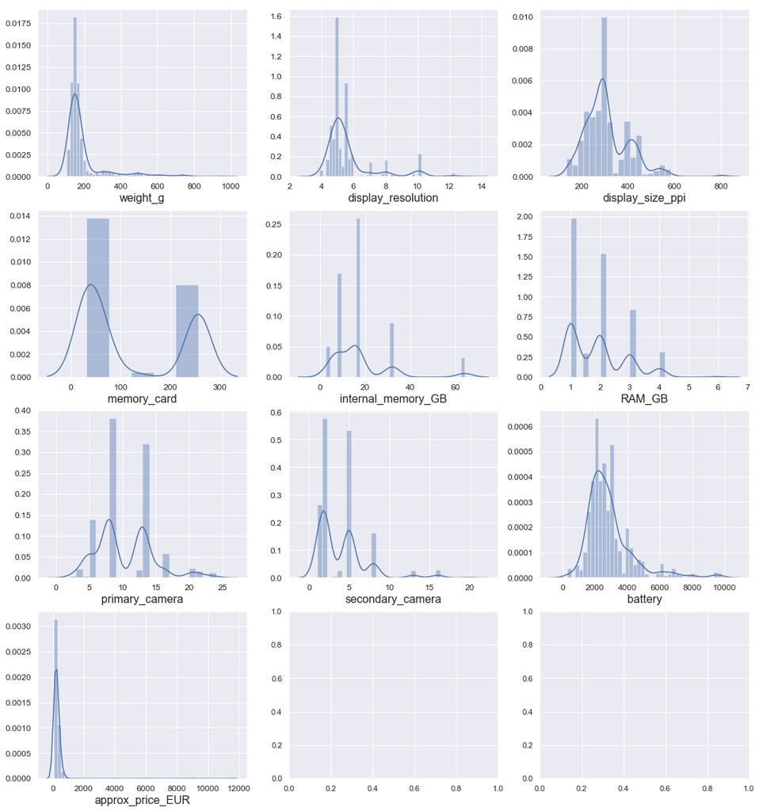

```python
import matplotlib.pyplot as plt
%matplotlib inline
import seaborn as sns
sns.set()
import numpy as np
import warnings
warnings.filterwarnings('ignore')

def plot_distribution(data, features):
    i = 0
    plt.figure()
    col = 3
    row = int(np.ceil(len(features)/col))
    fig, ax = plt.subplots(row,col,figsize=(18,20))

    for feature in features:
        i += 1
        plt.subplot(row,col,i);
        sns.distplot(tuple(data[feature]))
        plt.xlabel(feature, fontsize=16)
        locs, labels = plt.xticks()
        plt.tick_params(axis='x', which='major', labelsize=12)
        plt.tick_params(axis='y', which='major', labelsize=12)
    plt.show();

plot_distribution(data_rgr, num_cols)
```

Is there any correlation between the numeric columns?

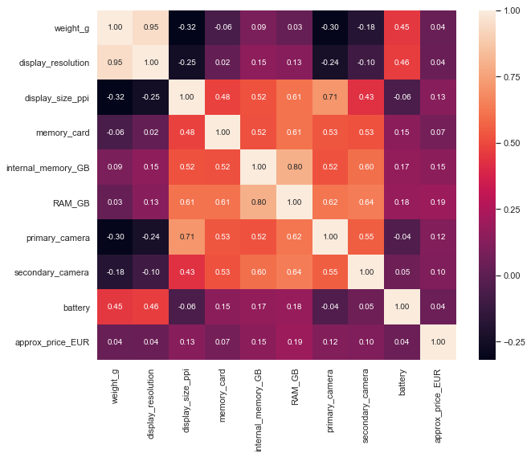

```python
corr = data_rgr[num_cols].corr()
fig, ax = plt.subplots(figsize=(10,8))
sns.heatmap(corr,
            xticklabels=corr.columns.values,
            yticklabels=corr.columns.values,
            annot=True, fmt=".2f");
```

What about the categorical columns?

```python
cat_cols = data_rgr.select_dtypes('O').columns
```

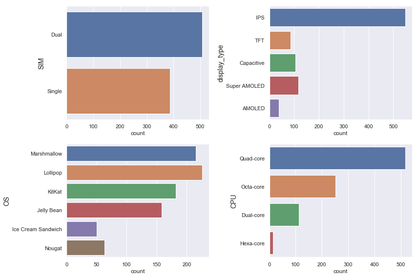

```python
def count_plot(data, features):
    i = 0
    plt.figure()
    col = 2
    row = int(np.ceil(len(features)/col))
    fig, ax = plt.subplots(row,col,figsize=(12,8))

    for feature in features:
        i += 1
        plt.subplot(row,col,i);
        ax = sns.countplot(data=data_rgr,y=feature)
        ax.set_yticklabels(ax.get_yticklabels())
        plt.tight_layout()
        plt.ylabel(feature, fontsize=14)
    plt.show();

count_plot(data_rgr, cat_cols)
```

### Step 3: Preprocessing

Are there any **missing values**?

```python
pd.DataFrame(data_rgr.isnull().sum(), columns=['Missing Values'])
```

|  | Missing Values |
| --- | --- |
| weight_g | 0 |
| SIM | 0 |
| display_type | 0 |
| display_resolution | 0 |
| display_size_ppi | 0 |
| OS | 0 |
| CPU | 0 |
| memory_card | 0 |
| internal_memory_GB | 0 |
| RAM_GB | 0 |
| primary_camera | 0 |
| secondary_camera | 0 |
| battery | 0 |
| approx_price_EUR | 0 |

Now, we have to encode the **categorical features**.

**Note**:

- If you use any linear/distance/neural based model, use **OneHotEncoding**.
- If you use tree based model, you can use **LabelEncoder**.

```python
data_rgr_encoded = pd.get_dummies(data_rgr, columns=cat_cols, prefix=cat_cols)

print("Now our dataset has {} columns.".format(data_rgr_encoded.shape[1]))
```

```
Now our dataset has 27 columns.
```

```python
data_rgr_encoded.head()
```

|  | weight_g | display_resolution | display_size_ppi | memory_card | internal_memory_GB | RAM_GB | primary_camera | secondary_camera | battery | approx_price_EUR | SIM_Dual | SIM_Single | display_type_AMOLED | display_type_Capacitive | display_type_IPS | display_type_Super AMOLED | display_type_TFT | OS_Ice Cream Sandwich | OS_Jelly Bean | OS_KitKat | OS_Lollipop | OS_Marshmallow | OS_Nougat | CPU_Dual-core | CPU_Hexa-core | CPU_Octa-core | CPU_Quad-core |
| --- | --- | --- | --- | --- | --- | --- | --- | --- | --- | --- | --- | --- | --- | --- | --- | --- | --- | --- | --- | --- | --- | --- | --- | --- | --- | --- | --- |
| 0 | 260.0 | 7.0 | 210 | 128 | 16 | 2.0 | 13.0 | 2.0 | 3400 | 170 | 1 | 0 | 0 | 0 | 1 | 0 | 0 | 0 | 0 | 0 | 0 | 1 | 0 | 0 | 0 | 0 | 1 |
| 1 | 169.0 | 5.5 | 401 | 256 | 32 | 3.0 | 13.0 | 5.0 | 4080 | 250 | 1 | 0 | 0 | 0 | 1 | 0 | 0 | 0 | 0 | 0 | 0 | 1 | 0 | 0 | 0 | 1 | 0 |
| 2 | 166.0 | 5.5 | 267 | 32 | 32 | 3.0 | 13.0 | 13.0 | 4020 | 230 | 0 | 1 | 0 | 0 | 1 | 0 | 0 | 0 | 0 | 0 | 1 | 0 | 0 | 0 | 0 | 1 | 0 |
| 3 | 125.0 | 5.0 | 294 | 32 | 8 | 1.0 | 8.0 | 5.0 | 2000 | 110 | 1 | 0 | 0 | 0 | 1 | 0 | 0 | 0 | 0 | 0 | 0 | 1 | 0 | 0 | 0 | 0 | 1 |
| 4 | 353.8 | 8.0 | 283 | 256 | 32 | 2.0 | 5.0 | 2.0 | 4420 | 350 | 0 | 1 | 0 | 0 | 1 | 0 | 0 | 0 | 0 | 0 | 1 | 0 | 0 | 0 | 0 | 0 | 1 |

Now, it's time for **data segregation**. We need to separate the feature columns and target colum.

```python
X = data_rgr_encoded.loc[:, data_rgr_encoded.columns!='approx_price_EUR']
y = data_rgr_encoded.loc[:, data_rgr_encoded.columns=='approx_price_EUR']
```

We have seen from the distribution plot (in Exploration section) that most of the features are not well distributed and have variety of ranges. This form of data can confuse the linear/distance based models. That is why we need **Normalize** our data.

```python
from sklearn.preprocessing import Normalizer

scaler = Normalizer()
scaler.fit(X.values)
X_norm = scaler.transform(X.values)
X_norm_df = pd.DataFrame(X_norm, columns=X.columns)
```

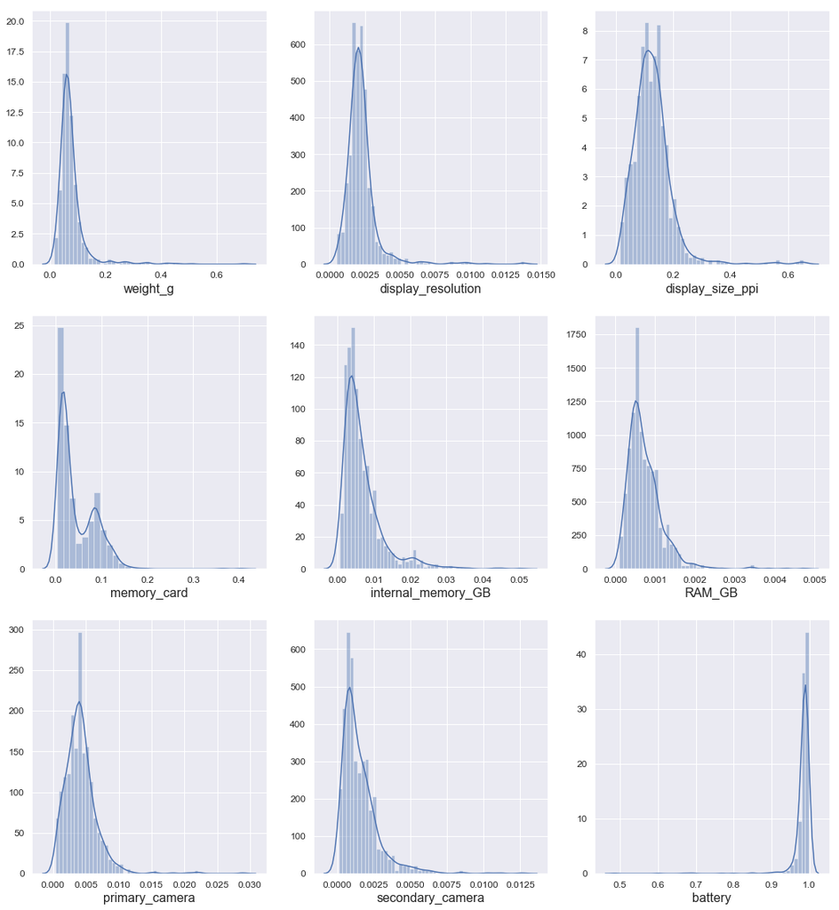

```python
plot_distribution(X_norm_df, num_cols[:-1])
```

Now we have to make dataset for **traing and testing**.

```python
from sklearn.model_selection import train_test_split

X_train, X_test, y_train, y_test = train_test_split(X_norm_df, y, test_size=0.20, random_state=1234)

print("""
X_train has {} data points.
y_train has {} data points.
X_test has {} data points.
y_test has {} data points.
""".format(X_train.shape[0], y_train.shape[0], X_test.shape[0], y_test.shape[0]))
```

```
X_train has 715 data points.
y_train has 715 data points.
X_test has 179 data points.
y_test has 179 data points.
```

### Step 4: Modeling

WOOOHAAA!! Here it is!

Finally, we've reached the modeling part! The easiest one!

We'll use **Linear Regression** algorithm for data modeling. This is the simplest, easiest and most utilized machine learning algorithms in the world!